# Hw05- Computation (Metropolis-Hastings)

Math 7393 Bayesian Statistics

Author

Brady Lamson

Published

March 19, 2025

Load the `igdata` data set from the **bayesutils** package. The data are a random sample of 100 values from a distribution with positive support and the observed values in the problems below.

# Problem 1

Assume $y_1, y_2, \ldots,y_{100} \mid \alpha, \beta \stackrel{i.i.d.}{\sim} \text{Inv-Gamma}(\alpha,\beta)$ with $\alpha=3$. Assume $\beta\sim\text{Gamma}(4, 4)$. Use the Metropolis-Hastings algorithm to approximate the posterior distribution of $\beta$.

## (a)

Decide on a proposal distribution for $\beta$. Construct a plot overlaying the proposal distribution and the unnormalized posterior density (where both have a similar scale). The proposal distribution should ideally have a similar shape, but more importantly, should be able to routinely propose values anywhere the unnormalized posterior density is positive.

Okay first we need the unnormalized posterior density.

$$\begin{align}
q(\beta | \vec{y}, \alpha=3) &\propto \left( \prod_{i=1}^{100} \frac{\beta^{3}}{\Gamma(3)} y_i^{-(3+1)}e^{-\beta/y_i} \right) \cdot \left( \frac{4^4}{\Gamma(4)} \beta^3 e^{-4\beta} \right) \\
&\propto \prod_{i=1}^{100} \beta^3 e^{-\beta/y_i} \cdot \beta^3 e^{-4\beta} \\
&= \beta^{300} e^{-\beta/\sum y_i} \beta^3 e^{-4\beta} \\
&= \beta^{303} \exp\left(-\left( \frac{\beta}{\sum y_i} + 4\beta \right)\right) \\
&= \beta^{303} \exp\left(-\beta\left( \frac{1}{\sum y_i} + 4 \right)\right) \\
\end{align}$$

We have the kernel of a gamma here. Thus we have the following unnormalized posterior:

$$q(\beta \mid \vec{y}, \alpha=3) \propto \text{Gamma}\left(304,4+ \sum\frac{1}{y_i}\right)$$

**Setting everything up**

```r
data_sum <- sum(1/igdata)
post_alpha <- 304
post_beta <- data_sum + 4
theta_support <- seq(3, 6, length=1000) # found these values by tinkering

q_post <- function(theta, alpha, beta, const=1) {
    density <- dgamma(theta, shape=alpha, rate=beta)
    return(density / const)
}

prior_densities <- dgamma(theta_support, shape=4, rate=4)
posterior_densities <- q_post(theta_support, post_alpha, post_beta)
df <- data.frame(
    theta=theta_support,
    qpost = posterior_densities,
    pprior = prior_densities
)
```

**Plots**

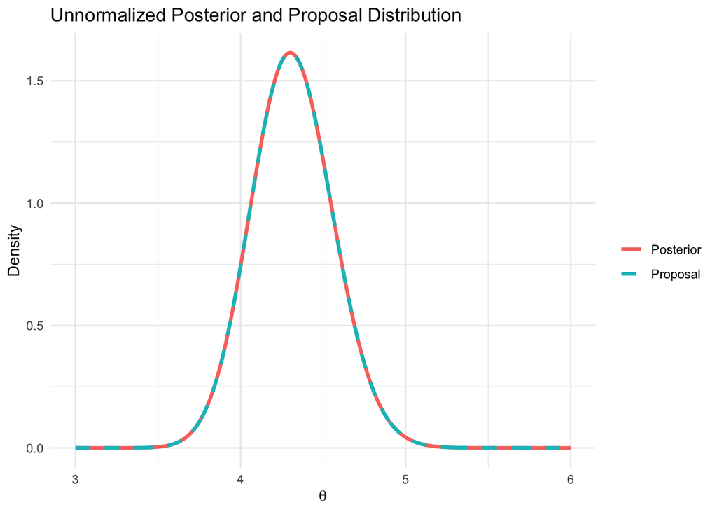

```r
line_size <- 1.2
ggplot(df, aes(x = theta)) +
    geom_line(aes(y = qpost, color = "Posterior"), linewidth = line_size) +
    geom_line(aes(y = qpost, color = "Proposal"), linewidth = line_size, linetype="dashed") +
    labs(
        x = TeX(r'($\theta$)'),
        y = "Density",
        title = "Unnormalized Posterior and Proposal Distribution",
        color = ""
    ) +
    # scale_x_continuous(breaks=seq(0,1,0.1)) +
    theme_minimal() +
    theme(legend.position = "right")
```

## (b)

What proposal distribution did you decide to use?

So I don’t know, I’m just going to use the unnormalized posterior because frankly I’m confused. There is nothing that indicates that I can’t do this, so I will.

Note that I did try using the prior as a proposal which did not go well. Very poor convergence behavior. It’s also worth stating that most times we won’t be able to use the posterior as the proposal because it will be some unknown distribution that is hard to sample from, but in this situation we can.

## (c)

Run 5 MCMC chains with a range of starting values for at least 100,000 iterations. Discard the first half of each chain as warmup. Then combine the results into an `mcmc.list` and use the `summary` function to summarize the results.

B = 100000

For this I will be shamelessly stealing your independence chain code and modifying it to fit my needs.

**MH Algorithm Code**

```r
mh = function(B, start, jump_param) {
    # Initialize the chain
    theta = numeric(B + 1)
    theta[1] = start

    # Extract parameters of jump dist
    prop_alpha <- jump_param[1]
    prop_beta <- jump_param[2]

    # Posterior values
    data_sum <- sum(1/igdata) #igdata is a vector
    post_alpha <- 304
    post_beta <- data_sum + 4

    # The algorithm itself
    for (i in 2:length(theta)) {
        # Sample from the proposal dist:
        theta_star = rgamma(1, shape = prop_alpha, rate = prop_beta)

        # Calculate the acceptance ratio
        num_logr = dgamma(theta_star, shape = post_alpha, rate = post_beta, log = T) -
            dgamma(theta_star, shape = prop_alpha, rate = prop_beta, log = T)

        den_logr = dgamma(theta[i - 1], shape = post_alpha, rate = post_beta, log = T) -
            dgamma(theta[i - 1], shape = prop_alpha, rate = prop_beta, log=T)

        logr = num_logr - den_logr

        # Accept or reject the proposal
        if (log(runif(1)) <= min(logr, 0)) {
            theta[i] = theta_star
        } else {theta[i] = theta[i - 1]}
    }
    return(theta)
}
```

**Running the chains**

```r
set.seed(100)
B <- 100000
keep = (B/2 + 1):(B + 1)
jpar <- c(post_alpha, post_beta) # Using posterior as proposal

chain1 = mh(B, start = 0.01, jump_param = jpar)
chain2 = mh(B, start = 3, jump_param = jpar)
chain3 = mh(B, start = 6, jump_param = jpar)
chain4 = mh(B, start = 9, jump_param = jpar)
chain5 = mh(B, start = 1, jump_param = jpar)

mc = mcmc.list(mcmc(chain1[keep]),
               mcmc(chain2[keep]),
               mcmc(chain3[keep]),
               mcmc(chain4[keep]),
               mcmc(chain5[keep]))

summary(mc)
```

```
Iterations = 1:50001
Thinning interval = 1
Number of chains = 5
Sample size per chain = 50001

1. Empirical mean and standard deviation for each variable,
   plus standard error of the mean:

          Mean             SD       Naive SE Time-series SE
     4.3160384      0.2472040      0.0004944      0.0004936

2. Quantiles for each variable:

 2.5%   25%   50%   75% 97.5%
3.844 4.147 4.311 4.481 4.812
```

## (d)

Assess convergence of your chains using trace plots (don’t actually provide this though, because it will make the pdf file much larger), effective sample size, and the $\hat{R}$ statistic.

```r
effectiveSize(mc)
```

```
    var1
250915.2
```

```r
coda::gelman.diag(mc, autoburnin=F)
```

```
Potential scale reduction factors:

     Point est. Upper C.I.
[1,]          1          1
```

The trace plot seems to navigate the parameter space well on all chains. Based on what I can see we didn’t have huge issues with the chains getting stuck. I saw what that looked like when using the prior as the proposal and this trace plot looks a lot better.

The $\hat{R}$ also is at 1 which indicates convergence.

This should be unsurprising as I used the un-normalized posterior *as* the proposal distribution. We won’t always be able to do this but, like I said earlier, it seems to be fair game in this situation.

# Problem 2

Assume $y_1, y_2, \ldots,y_{100} \mid \alpha, \beta \stackrel{i.i.d.}{\sim} \text{Inv-Gamma}(\alpha,\beta)$ with $\beta=4$. Assume $\alpha\sim\text{U}(1, 5)$. Use the Metropolis-Hastings algorithm to approximate the posterior distribution of $\alpha$.

## (a)

Decide on a proposal distribution for $\alpha$. Construct a plot overlaying the proposal distribution and the unnormalized posterior density (where both have a similar scale). The proposal distribution should ideally have a similar shape, but more importantly, should be able to routinely propose values anywhere the unnormalized posterior density is positive.

Let’s figure out our posterior distribution.

$$\begin{align}
q(\alpha | \vec{y}, \beta=4) &\propto \left( \prod_{i=1}^{100} \frac{4^{\alpha}}{\Gamma(\alpha)} y_i^{-(\alpha+1)}e^{-4/y_i} \right) \frac{1}{4} \\
&\propto \prod_{i=1}^{100} \frac{4^{\alpha}}{\Gamma(\alpha)} y_i^{-(\alpha+1)} \\
&= \left( \frac{4^{\alpha}}{\Gamma(\alpha)} \right)^{100} \prod_{i=1}^{100} y_i^{-(\alpha+1)} \\
\ln q(\alpha | \vec{y}, \beta=4) &\propto 100\alpha\ln(4) - 100\ln(\Gamma(\alpha)) - (\alpha+1) \sum_{i=1}^{100} \ln(y_i)
\end{align}$$

**Setting everything up**

```r
theta_support <- seq(1, 4, length=1000)

q_post_log <- function(theta, data_sum) {
    # Theta must be greater than 0.
    if (min(theta) <= 0) {
        return(0)
    }
    log_density <- 100*theta*log(4) - 100*log(gamma(theta)) - (theta+1)*data_sum
    return(log_density)
}

prior_densities <- dunif(theta_support, min = 1, max=5)
posterior_densities <- q_post_log(theta_support, data_sum=sum(log(igdata)))
proposal_densities <- dnorm(theta_support, mean=2.5, sd=0.25)
df <- data.frame(
    theta=theta_support,
    qpost = posterior_densities,
    pprior = prior_densities,
    pprop = proposal_densities
)
```

**Plots**

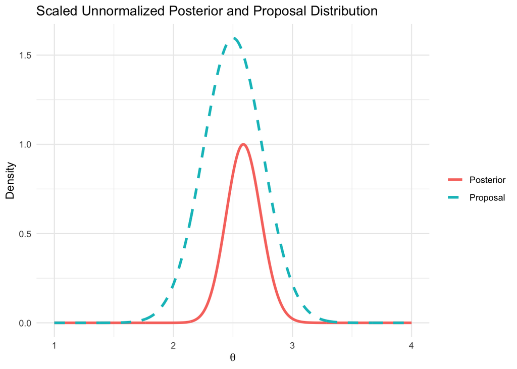

```r
line_size <- 1.2
ggplot(df, aes(x = theta)) +
    geom_line(aes(y = exp(qpost) / max(exp(qpost)), color = "Posterior"), linewidth = line_size) +
    geom_line(aes(y = pprop, color = "Proposal"), linewidth = line_size, linetype="dashed") +
    labs(
        x = TeX(r'($\theta$)'),
        y = "Density",
        title = "Scaled Unnormalized Posterior and Proposal Distribution",
        color = ""
    ) +
    theme_minimal() +
    theme(legend.position = "right")
```

## (b)

What proposal distribution did you decide to use?

## (c)

Run 5 MCMC chains with a range of starting values for at least 100,000 iterations. Discard the first half of each chain as warmup. Then combine the results into an `mcmc.list` and use the `summary` function to summarize the results.

**MH Algorithm Code**

```r
mh = function(B, start, jump_param) {
    # Initialize the chain
    theta = numeric(B + 1)
    theta[1] = start

    # Extract parameters of jump dist
    prop_mu <- jump_param[1]
    prop_sigma <- jump_param[2]

    # Posterior values
    data_sum <- sum(log(igdata))

    # The algorithm itself
    for (i in 2:length(theta)) {
        # Sample from the proposal dist:
        theta_star = rnorm(1, mean=prop_mu, sd=prop_sigma)
        if(theta_star > 0) {
            # Calculate the acceptance ratio
            num_logr <- q_post_log(theta_star, data_sum) - dnorm(theta_star, mean=prop_mu, sd=prop_sigma, log=T)
            den_logr <- q_post_log(theta[i-1], data_sum) - dnorm(theta[i-1], mean=prop_mu, sd=prop_sigma, log=T)
            logr = num_logr - den_logr
        }
        # This prevents theta<0 from being accepted and avoids any risk of underflow or computational error.
        else {logr = 0}

        # Accept or reject the proposal
        if (log(runif(1)) <= min(logr, 0)) {
            theta[i] = theta_star
        } else {theta[i] = theta[i - 1]}
    }
    return(theta)
}
```

**Running the chains**

```r
set.seed(100)
B <- 100000
keep = (B/2 + 1):(B + 1)
jpar <- c(2.5, 0.25) # N(2.5, 0.25^2)

chain1 = mh(B, start = 0.01, jump_param = jpar)
chain2 = mh(B, start = 1, jump_param = jpar)
chain3 = mh(B, start = 3, jump_param = jpar)
chain4 = mh(B, start = 5, jump_param = jpar)
chain5 = mh(B, start = 7, jump_param = jpar)

mc = mcmc.list(mcmc(chain1[keep]),
               mcmc(chain2[keep]),
               mcmc(chain3[keep]),
               mcmc(chain4[keep]),
               mcmc(chain5[keep]))

summary(mc)
```

```
Iterations = 1:50001
Thinning interval = 1
Number of chains = 5
Sample size per chain = 50001

1. Empirical mean and standard deviation for each variable,
   plus standard error of the mean:

          Mean             SD       Naive SE Time-series SE
     2.5917038      0.1458875      0.0002918      0.0003968

2. Quantiles for each variable:

 2.5%   25%   50%   75% 97.5%
2.310 2.493 2.590 2.689 2.883
```

## (d)

Assess convergence of your chains using the Heidelberg-Welch, Raftery-Lewis, and Geweke diagnostics.

```r
coda::heidel.diag(mc)
```

```
[[1]]

     Stationarity start     p-value
     test         iteration
var1 passed       1         0.573

     Halfwidth Mean Halfwidth
     test
var1 passed    2.59 0.00175

[[2]]

     Stationarity start     p-value
     test         iteration
var1 passed       1         0.942

     Halfwidth Mean Halfwidth
     test
var1 passed    2.59 0.00173

[[3]]

     Stationarity start     p-value
     test         iteration
var1 passed       1         0.296

     Halfwidth Mean Halfwidth
     test
var1 passed    2.59 0.00173

[[4]]

     Stationarity start     p-value
     test         iteration
var1 passed       1         0.4

     Halfwidth Mean Halfwidth
     test
var1 passed    2.59 0.00172

[[5]]

     Stationarity start     p-value
     test         iteration
var1 passed       1         0.0533

     Halfwidth Mean Halfwidth
     test
var1 passed    2.59 0.00176
```

```r
coda::raftery.diag(mc)
```

```
[[1]]

Quantile (q) = 0.025
Accuracy (r) = +/- 0.005
Probability (s) = 0.95

 Burn-in  Total Lower bound  Dependence
 (M)      (N)   (Nmin)       factor (I)
 5        5597  3746         1.49


[[2]]

Quantile (q) = 0.025
Accuracy (r) = +/- 0.005
Probability (s) = 0.95

 Burn-in  Total Lower bound  Dependence
 (M)      (N)   (Nmin)       factor (I)
 5        5772  3746         1.54


[[3]]

Quantile (q) = 0.025
Accuracy (r) = +/- 0.005
Probability (s) = 0.95

 Burn-in  Total Lower bound  Dependence
 (M)      (N)   (Nmin)       factor (I)
 5        5898  3746         1.57


[[4]]

Quantile (q) = 0.025
Accuracy (r) = +/- 0.005
Probability (s) = 0.95

 Burn-in  Total Lower bound  Dependence
 (M)      (N)   (Nmin)       factor (I)
 5        5782  3746         1.54


[[5]]

Quantile (q) = 0.025
Accuracy (r) = +/- 0.005
Probability (s) = 0.95

 Burn-in  Total Lower bound  Dependence
 (M)      (N)   (Nmin)       factor (I)
 5        5923  3746         1.58
```

```r
coda::geweke.diag(mc)
```

```
[[1]]

Fraction in 1st window = 0.1
Fraction in 2nd window = 0.5

   var1
-0.5253


[[2]]

Fraction in 1st window = 0.1
Fraction in 2nd window = 0.5

  var1
-1.004


[[3]]

Fraction in 1st window = 0.1
Fraction in 2nd window = 0.5

 var1
2.082


[[4]]

Fraction in 1st window = 0.1
Fraction in 2nd window = 0.5

   var1
-0.3861


[[5]]

Fraction in 1st window = 0.1
Fraction in 2nd window = 0.5

 var1
1.559
```

All of these diagnostics check out and seem to be within acceptable values.

All of the heidel tests pass. The dependence factors are all less than 5. And all of the z-scores are between -2,2. There’s one thats slightly larger than 2 but only barely.